# Praca domowa 2

Ola Paluszynska

13 marca 2017

## Rozkład rozstępu dla testu HSD

Mamy porównać rozkład rozstępu dla testu HSD pomiędzy przypadkiem zrównoważonym i niezrównoważonym. W tym celu symulacyjnie $r$ razy stworzymy dane odpowiadające tym dwóm przypadkom i obliczymy rozstęp średnich w grupach.

### Dane

W przypadku zrównoważonym mamy $k$ grup, z których każda zawiera $n$ obserwacji. Jeśli chodzi o przypadek niezrównoważony, to wyróżnimy dwie sytuacje: w pierwszej każda grupa ma inną liczebność, powiedzmy $n_k = k \cdot n$, a w drugiej jedna grupa (powiedzmy pierwsza) ma dominującą liczebność `factor`$\cdot n$, a pozostałe są znacznie mniejsze, o liczebności $n$ (tak często bywa w danych ankietowych kiedy jedna kategoria jest w pewnym sensie “standardowa”).

W każdym z tych przypadków losujemy obserwacje z rozkładu normalnego o średniej $\mu$ i wariancji $\sigma^2$.

### Funkcje pomocnicze

```r
rozklad_HSD_balanced <- function(r = 10000, k = 5, n = 100, mu = 0, sigma = 1){
    replicate(r, {
        df <- data.frame(x = rnorm(k*n, mu, sigma), group = as.vector(sapply(1:k, function(i) rep(i, n))))
        df$group <- as.factor(df$group)
        return(max(by(df$x, df$group, mean))-min(by(df$x, df$group, mean)))
    })
}
rozklad_HSD_unbalanced1 <- function(r = 10000, k = 5, n = 100, mu = 0, sigma = 1){
    replicate(r, {
        df <- data.frame(x = rnorm(sum((1:k)*n), mu, sigma), group = unlist(sapply(1:k, function(i) rep(i, i*n))))
        df$group <- as.factor(df$group)
        return(max(by(df$x, df$group, mean))-min(by(df$x, df$group, mean)))
    })
}
rozklad_HSD_unbalanced2 <- function(r = 10000, k = 5, n = 100, mu = 0, sigma = 1, factor = 5){
    replicate(r, {
        df <- data.frame(x = rnorm((k+factor-1)*n, mu, sigma), group = c(rep(1, factor*n), as.vector(sapply(2:k, function(i) rep(i, n)))))
        df$group <- as.factor(df$group)
        return(max(by(df$x, df$group, mean))-min(by(df$x, df$group, mean)))
    })
}
```

### Symulacje

Teraz zbadamy rozkład rozstępu dla kilku zestawów parametrów zadania.

```r
library(ggplot2)
library(moments)
r <- 10000 # liczba replikacji
set.seed(2017)
```

#### 5 grup, n = 100, factor = 5

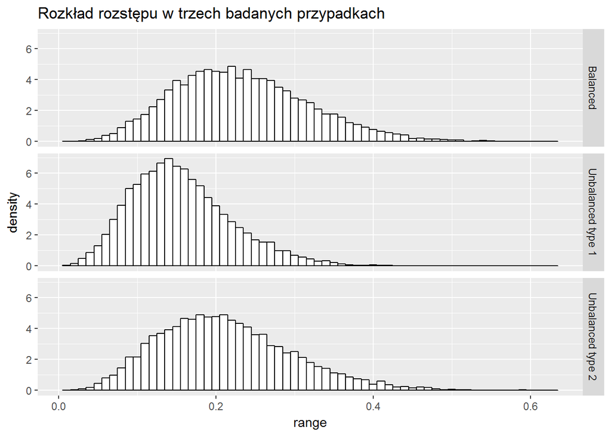

```r
data <- data.frame(range = c(rozklad_HSD_balanced(r), rozklad_HSD_unbalanced1(r), rozklad_HSD_unbalanced2(r)), type = c(rep("Balanced", r), rep("Unbalanced type 1", r), rep("Unbalanced type 2", r)))
ggplot(data, aes(x = range)) + geom_histogram(aes(y = ..density..), binwidth = 0.01, color = "black", fill = "white") + ggtitle("Rozkład rozstępu w trzech badanych przypadkach") + facet_grid(type ~ .)
```

```r
by(data$range, data$type, skewness)
```

```
## data$type: Balanced
## [1] 0.4682305
## --------------------------------------------------------
## data$type: Unbalanced type 1
## [1] 0.7119423
## --------------------------------------------------------
## data$type: Unbalanced type 2
## [1] 0.5756511
```

```r
by(data$range, data$type, kurtosis)
```

```
## data$type: Balanced
## [1] 3.105736
## --------------------------------------------------------
## data$type: Unbalanced type 1
## [1] 3.720351
## --------------------------------------------------------
## data$type: Unbalanced type 2
## [1] 3.287753
```

Dla tych parametrów widzimy, że przy pierwszym rodzaju niezrównoważenia liczebności grup rozkład wyraźnie odbiega od pożądanego (pierwszy wykres) - jest silnie prawoskośny i skupiony wokół niższych wartości, co oznacza, że dla tego rozkładu kwantyle $1-\alpha$ będą z reguły niższe, a więc będziemy rzadziej odrzucać hipotezę zerową. Natomiast niezrównoważenie liczebności typu drugiego (jedna grupa większa od pozostałych) nie powoduje wyraźnej zmiany rozkładu w stosunku do przypadku równolicznych grup (jest on bardziej prawoskośny i spiczasty, ale na rysunku nie widać specjalnych różnic).

#### 5 grup, n = 100, factor = 20

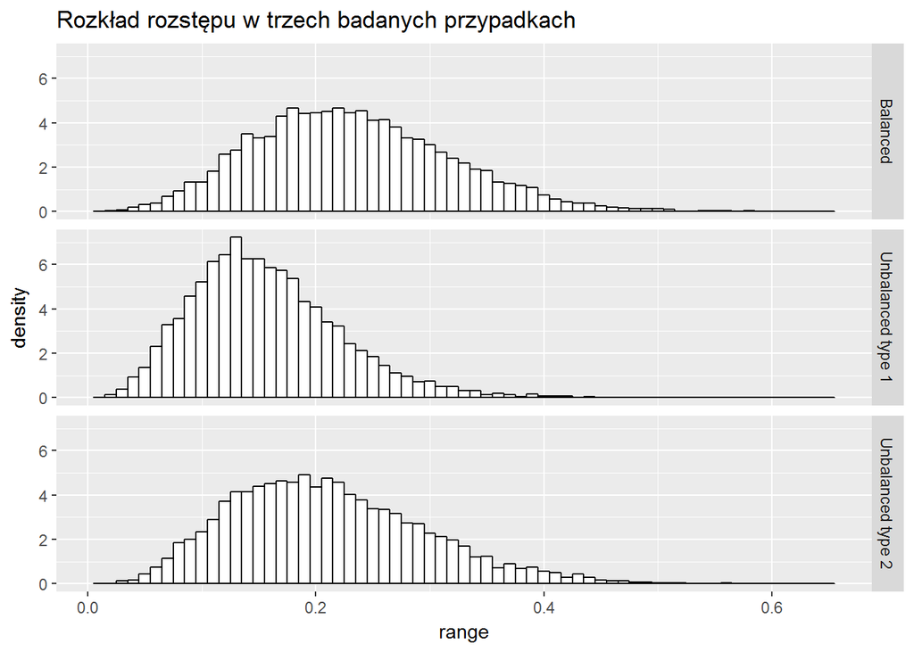

```r
data <- data.frame(range = c(rozklad_HSD_balanced(r), rozklad_HSD_unbalanced1(r), rozklad_HSD_unbalanced2(r, factor = 20)), type = c(rep("Balanced", r), rep("Unbalanced type 1", r), rep("Unbalanced type 2", r)))
ggplot(data, aes(x = range)) + geom_histogram(aes(y = ..density..), binwidth = 0.01, color = "black", fill = "white") + ggtitle("Rozkład rozstępu w trzech badanych przypadkach") + facet_grid(type ~ .)
```

```r
by(data$range, data$type, skewness)
```

```
## data$type: Balanced
## [1] 0.4636963
## --------------------------------------------------------
## data$type: Unbalanced type 1
## [1] 0.7652108
## --------------------------------------------------------
## data$type: Unbalanced type 2
## [1] 0.5641354
```

```r
by(data$range, data$type, kurtosis)
```

```
## data$type: Balanced
## [1] 3.22756
## --------------------------------------------------------
## data$type: Unbalanced type 1
## [1] 3.91446
## --------------------------------------------------------
## data$type: Unbalanced type 2
## [1] 3.165341
```

Na powyższym wykresie widać, że znaczne zwiększenie liczebności najliczniejszej grupy niewiele zmiena - rozkład rozstępu trochę odbiega od rozkładu Tukey’a (jest bardziej prawoskośny, mniej więcej w połowie drogi między pozostałymi przypadkami; kurtozą się wiele nie różni), ale jest mimo wszystko dość podobny wizualnie.

#### 5 grup, n = 20, factor = 5

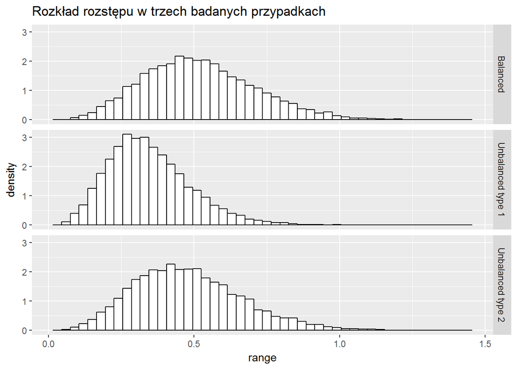

```r
data <- data.frame(range = c(rozklad_HSD_balanced(r, n = 20), rozklad_HSD_unbalanced1(r, n = 20), rozklad_HSD_unbalanced2(r, n = 20)), type = c(rep("Balanced", r), rep("Unbalanced type 1", r), rep("Unbalanced type 2", r)))
ggplot(data, aes(x = range)) + geom_histogram(aes(y = ..density..), binwidth = 0.03, color = "black", fill = "white") + ggtitle("Rozkład rozstępu w trzech badanych przypadkach") + facet_grid(type ~ .)
```

```r
by(data$range, data$type, skewness)
```

```
## data$type: Balanced
## [1] 0.4428279
## --------------------------------------------------------
## data$type: Unbalanced type 1
## [1] 0.7786557
## --------------------------------------------------------
## data$type: Unbalanced type 2
## [1] 0.5550787
```

```r
by(data$range, data$type, kurtosis)
```

```
## data$type: Balanced
## [1] 3.097567
## --------------------------------------------------------
## data$type: Unbalanced type 1
## [1] 3.99648
## --------------------------------------------------------
## data$type: Unbalanced type 2
## [1] 3.322004
```

Widać, że zmiana wielkości próby niewiele zmienia w stosunku do wyjściowej sytuacji.

#### 20 grup, n = 100, factor = 5

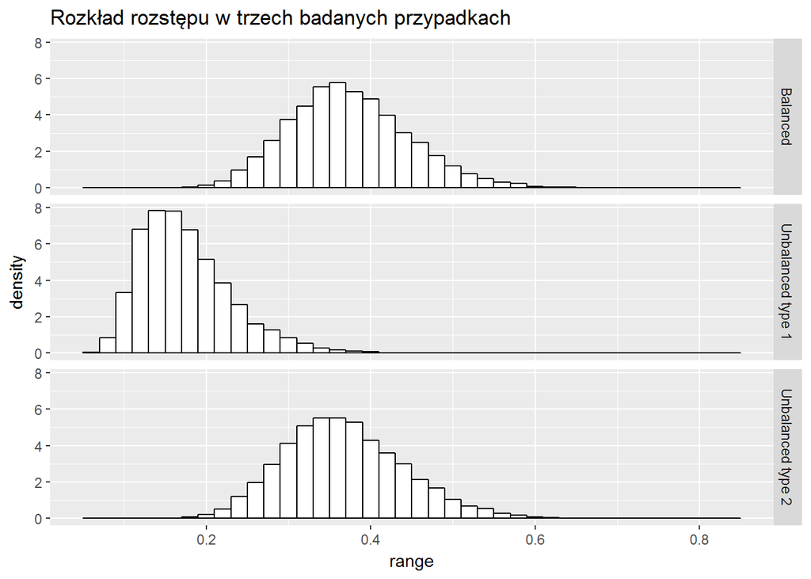

```r
data <- data.frame(range = c(rozklad_HSD_balanced(r, k = 20), rozklad_HSD_unbalanced1(r, k = 20), rozklad_HSD_unbalanced2(r, k = 20)), type = c(rep("Balanced", r), rep("Unbalanced type 1", r), rep("Unbalanced type 2", r)))
ggplot(data, aes(x = range)) + geom_histogram(aes(y = ..density..), binwidth = 0.02, color = "black", fill = "white") + ggtitle("Rozkład rozstępu w trzech badanych przypadkach") + facet_grid(type ~ .)
```

```r
by(data$range, data$type, skewness)
```

```
## data$type: Balanced
## [1] 0.3930101
## --------------------------------------------------------
## data$type: Unbalanced type 1
## [1] 0.9484475
## --------------------------------------------------------
## data$type: Unbalanced type 2
## [1] 0.4420998
```

```r
by(data$range, data$type, kurtosis)
```

```
## data$type: Balanced
## [1] 3.190659
## --------------------------------------------------------
## data$type: Unbalanced type 1
## [1] 4.097546
## --------------------------------------------------------
## data$type: Unbalanced type 2
## [1] 3.367498
```

Zwiększenie liczby grup to ewidentnie parametr, na który przedstawiane wyniki są wrażliwe (warto zaznaczyć, że konstrukcja zbioru danych przypadku type 1 powoduje że wraz ze wzrostem liczby grup rośnie zróżnicowanie ich wielkości). Przy 20 grupach niezrównoważenie pierwszego typu ma ponad dwa razy wyższą skośność niż przy zrównoważeniu, jest również o wiele bardziej spiczaste, a nośnik rozkładu pokrywa się z nośnikiem z przypadku zrównoważenia w niewielkim stopniu. Ten przypadek pokazuje jak wielkim błędem jest stosowanie testu Tukey’a w przypadku ostro niezrównoważonej wielkości grup.

Jak widać, niezrównoważenie drugiego typu wciąż nie powoduje kolosalnych zmian rozkładu w stosunku do przypadku zrównoważonego.